# Distributions - measures of centre

# 1 Learning Objectives

- Understand meaning of the term “distribution”
- Understand the different measures of centre for a distribution - mean, mode, median
- Be able to identify unimodal, bimodal, uniform, left and right skewed distributions
- Know the correct measure of centre for a skewed distribution and/or in the presence of outliers
- Be able to link distributions to probabilities

**Duration - 40 minutes**

# 2 Distributions

So far this week we’ve learnt about probability as a concept, and how to calculate the probability of an observation occuring within a dataset. In practice though we often come across the concept of a probability **distribution**. In the following lessons, we will learn more about what a probability distribution is, what kind of distributions we encounter, and why knowing about them is incredibly useful for data analysis.

# 3 What is a distribution?

Yesterday we learned about random variables and their associated frequency and probability. For example, a random variable could be the outcome of the roll of a die, the flip of a coin, or the colour blindness status of an individual.

A distribution is a list of all of the possible outcomes of a random variable along with either their corresponding frequency or probability values (we would speak of the **frequency distribution** or **probability distribution** respectively).

Defined either way, the distribution gives insight into **how likely** or **how common** the various outcomes are.

As ever, an example should help make the concept clear. Imagine an experiment in which we toss three unbiased coins. The sample space contains eight outcomes:

```r
library(prob)
library(tidyverse)
```

```r
s_three_coins <- tosscoin(3)
s_three_coins
```

| toss1 | toss2 | toss3 |
| --- | --- | --- |
| H | H | H |
| T | H | H |
| H | T | H |
| T | T | H |
| H | H | T |
| T | H | T |
| H | T | T |
| T | T | T |

> **Task - 2 mins** what is the probability of each of the eight outcomes if all of the coins are unbiased? What does ‘unbiased’ mean here? Why is it important that each of the coins are unbiased in this calculation?

> **Solution**

> We did calculations like this on day 1 of this week.
> - If all of the coins are unbiased (i.e. $\textrm{prob}(H)=\textrm{prob}(T)=\frac{1}{2}$) then each outcome in the sample space has equal probability! There are eight outcomes and so the probability of each is $\textrm{prob}=\frac{1}{8}$.
> - If any or all of the coins were biased (i.e. $\textrm{prob}(H) \neq \textrm{prob}(T)$), we couldn’t compute probabilities of outcomes in this way.  
>   e.g. coin 3 is biased, so $\textrm{prob}(H,H,H) \neq \textrm{prob}(H,H,T)$

Each outcome has a probability of $\frac{1}{8}$ (or 0.125). If we plot this, we’ll get a so-called **uniform probability distribution**, ‘uniform’ because each of the outcomes has the **same** probability.

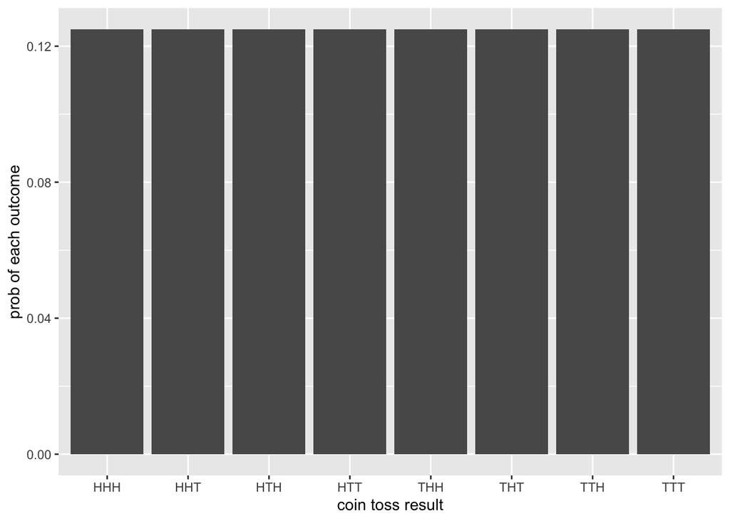

```r
s_three_coins <- s_three_coins %>%
  mutate(label = str_c(toss1, toss2, toss3, sep = "")) %>%
  mutate(prob = 1 / n())

s_three_coins %>%
  ggplot(aes(x = label, y = prob)) +
  geom_col() +
  xlab("coin toss result") +
  ylab ("prob of each outcome")
```

Now let’s do something much more interesting! What are the probabilities of getting 0 1, 2 or 3 heads on the toss of three unbiased coins?

```r
# first, we need to count the number of heads in each outcome
s_three_coins <- s_three_coins %>%
  mutate(num_heads = rowSums(. == "H"))

# then we can work out the probability associated with each combo
prob_num_heads <- s_three_coins %>%
  group_by(num_heads) %>%
  summarise(prob = sum(prob))

# show the probabilities of each
prob_num_heads
```

| num_heads | prob |
| --- | --- |
| 0 | 0.125 |
| 1 | 0.375 |
| 2 | 0.375 |
| 3 | 0.125 |

We’ve done quite a lot here, so let’s step through it slowly.

- First, we counted the number of heads in each outcome. We add a column to the original data frame with the number of heads.
- Next, we grouped outcomes by the number of heads they contained, and totalled probability in each group. This is equivalent to defining *four events*: `has_n_heads` where `n` is $0$, $1$, $2$ or $3$ and calculating the probability of each event.

Now let’s plot the probability distribution!

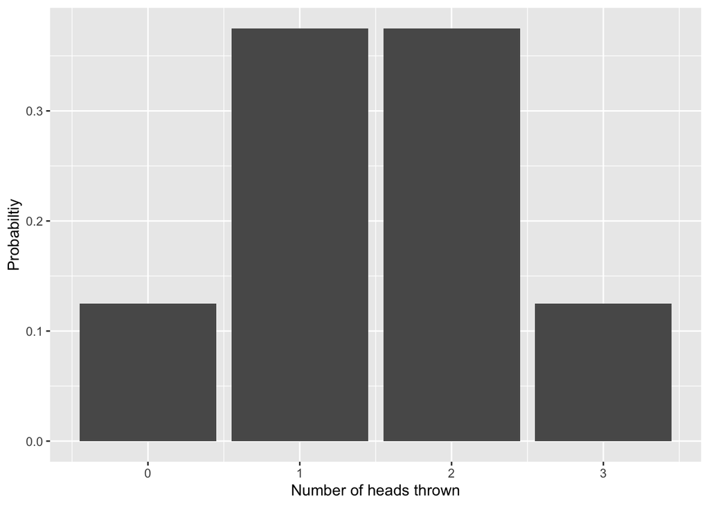

```r
prob_num_heads %>%
  ggplot(aes(x = num_heads, y = prob)) +
  geom_col() +
  xlab("Number of heads thrown") +
  ylab("Probabiltiy")
```

What does this tell us? The probability distribution we get is **not uniform**. One and two heads are each **three times more likely** than no heads or all heads. This is an example of a what we call a **discrete probability distribution**: ‘discrete’ because the events or outcomes are finite and countable. The alternative would be a **continuous** distribution: we’ll talk about those shortly.

**General properties of discrete probability distributions**

- On the $x$-axis we have outcomes or events
- On the $y$-axis we have the probability of each outcome or event
- The probabilities must sum to $1$

> **Task - 2 mins**

> Given the distribution we just calculated and plotted:
> 1. what is the probability that we get *zero or one head* on the toss of three coins?
> 2. what is the probability that we get *zero, one, two or three heads* on the toss of three coins?

> **Solution**
> 1. The probability required is $\textrm{prob}(\textrm{no heads})+\textrm{prob}(\textrm{one head}) = 0.125 + 0.375 = 0.5$
> 2. This event includes all outcomes, so the probability is $1$.

# 4 Measures of centrality: mean, median and mode

Now we have our distribution, we can start using it to summarise the data. To start with, we’re going to look at three measures of the ‘centre’ of a probability distribution. Each of the measures have their own advantages and disadvantages, which we will talk about later. First, we’ll define the measures.

We’ll work with a data set tracking daily sales of air conditioning units in a small business.

```r
library(janitor)
library(lubridate)

# read in dates as strings
air_con_sales <- read_csv("data/AirConSales.csv") %>%
  clean_names()

# then convert column to Date afterwards
air_con_sales <- air_con_sales %>%
  mutate(date = as.Date(date, format = "%m/%d/%Y"))

air_con_sales
```

| date | units_sold |
| --- | --- |
| 2018-06-05 | 0 |
| 2018-06-06 | 1 |
| 2018-06-07 | 0 |
| 2018-06-08 | 9 |
| 2018-06-09 | 3 |
| 2018-06-10 | 3 |
| 2018-06-11 | 4 |
| 2018-06-12 | 3 |
| 2018-06-13 | 4 |
| 2018-06-14 | 11 |

[output cut: 27 more lines]

Next, what we need is the total number of occurrences in our data. For this, we can use the `tabyl()` function we saw yesterday in the lesson on conditional probability. This time we’ll use it on a single variable `units_sold`, which is discrete numerical.

```r
sales_freq_table <- air_con_sales %>%
  tabyl(units_sold)
sales_freq_table
```

| units_sold | n | percent |
| --- | --- | --- |
| 0 | 3 | 0.08108108 |
| 1 | 2 | 0.05405405 |
| 2 | 2 | 0.05405405 |
| 3 | 9 | 0.24324324 |
| 4 | 8 | 0.21621622 |
| 6 | 3 | 0.08108108 |
| 8 | 1 | 0.02702703 |
| 9 | 1 | 0.02702703 |
| 10 | 2 | 0.05405405 |
| 11 | 3 | 0.08108108 |

[output cut: 2 more lines]

The last column is a bit misleadingly titled *‘percent’*: it is the relative frequency or proportion, i.e. the count `n` divided by the `sum(n)`

**Relative frequencies and empirical probabilities**

How do frequencies relate to probabilities? A **frequency** is the number of times a given observation occurs in a data set. A **relative frequency** is the fraction of times a particular observation occurs. **Relative frequencies** correspond to **empirical probabilities**. But how do empirical probabilities differ from probabilities as we understood them yesterday?

The best way to understand this is via an example. Imagine we have an unbiased die, which we roll $1000$ times, noting the results as we go. We know that the **theoretical probability** of each number is $1/6 = 0.166667$. However, the frequencies we actually rolled are:

```r
rolls <- sample(1:6, 1000, replace = TRUE)
freqs <- tabyl(rolls)
freqs
```

| rolls | n | percent |
| --- | --- | --- |
| 1 | 173 | 0.173 |
| 2 | 156 | 0.156 |
| 3 | 144 | 0.144 |
| 4 | 189 | 0.189 |
| 5 | 161 | 0.161 |
| 6 | 177 | 0.177 |

We get the **relative frequencies** by dividing the observed frequencies by the total number of rolls, which is what we see in the `percent` column, We can interpret these as **empirical probabilities**, ‘empirical’ in the sense of ‘obtained from observation’.

**If all we knew about this die were the results of these $1000$ rolls, the empirical probabilities would be our best estimate of the behaviour of the die**.

Now let’s plot the probability distribution:

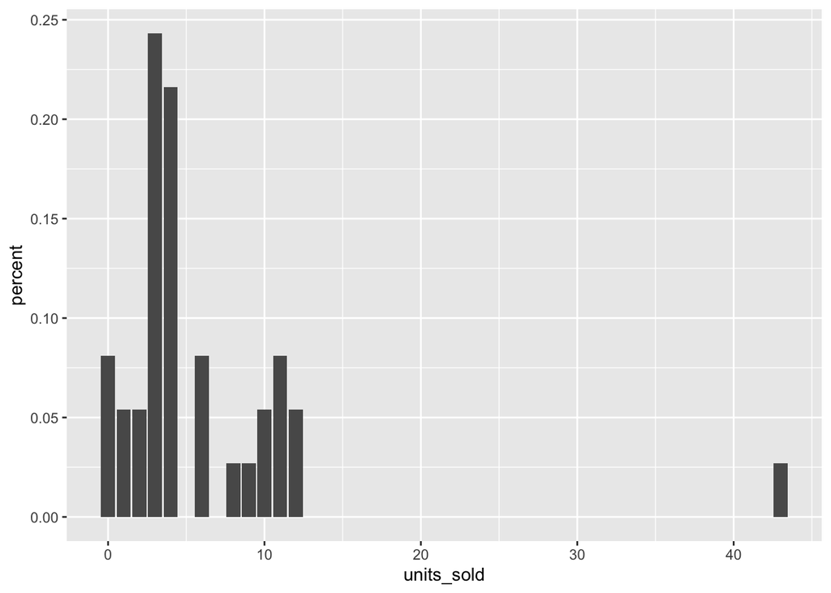

```r
sales_freq_table %>%
  ggplot(aes(x = units_sold, y = percent)) +
  geom_col()
```

Now we have our distribution, we can start looking at summaries of that distribution. First, definitions.

**Mean**: The mean is just another term for the average, defined as

$$\textrm{mean} = \frac{\textrm{sum of values}}{\textrm{no. of values}}$$

The mean is given the symbol

- $\mu$ for a population, and
- $\bar{x}$ for a sample.

**Mode**

The **mode** is the most likely value in the data set, i.e. the value that occurs most frequently. R has no built-in function to calculate the mode of a distribution (this is genuinely weird), but we can create one ourselves. We’ll use this in a minute to calculate all our stats.

```r
# SLACK THIS OUT
# let's make our mode function
get_mode <- function(data){

  tabled_data <- table(data)
  table_names <- names(tabled_data)

  return( table_names[tabled_data == max(tabled_data)] )

}
```

Let’s calculate all these values now:

```r
air_con_sales %>%
  summarise(mean_daily_sales = mean(units_sold),
            median_daily_sales = median(units_sold),
            mode_daily_sales = get_mode(units_sold))
```

| mean_daily_sales | median_daily_sales | mode_daily_sales |
| --- | --- | --- |
| 5.945946 | 4 | 3 |

So these are our results, and you can see that they are pretty different… if we look at the mean, we have a higher value than the median and mode. Why is this?

**Measures of centre and outliers**

Outliers are values that are a bit further away from the bulk of the data. Why mention outliers here? It turns out that **the three measures of distribution ‘centre’ show very different sensitivities to outliers!**

The key point is that **the mean is more heavily swayed by outliers than the median or the mode**. If we suspect our data set contains outliers, we should consider carefully which measure of centrality to use, and perhaps prefer the median to the mean. You can check whether or not your data contains outliers by plotting it and looking at the **distribution shape.**

# 5 Distribution shapes: unimodal and bimodal

A **unimodal** distribution is one in which there is **a single** ‘peak’ or ‘hump’ in the data. We can think of a mode as being a local peak in the distribution, so ‘unimodal’ just means ‘one-peaked’

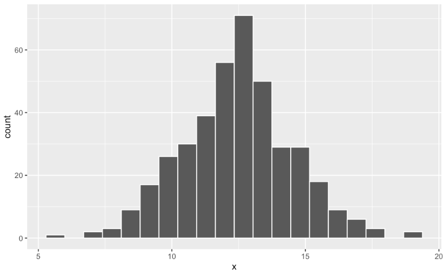

Here, we can see there is one clear peak in the distribution.

On the other hand, we might have a **bimodal** (‘two-peaked’) distribution.

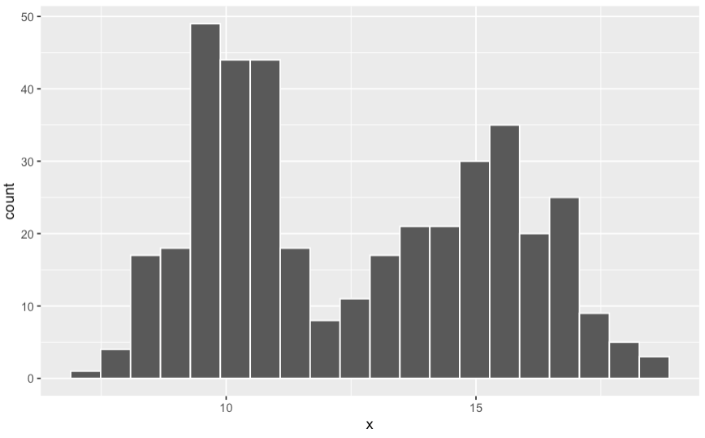

Here, you can see the two peaks in the data.

> **Task: 2 mins**

> Look back at the `AirConSales` distribution of daily sales figures and plot a histogram of the data. Is this unimodal or bimodal?

> **Answers**

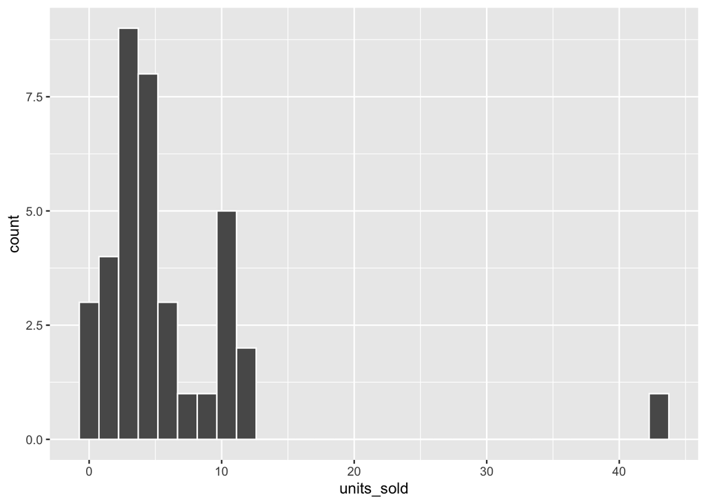

> ```r
> air_con_sales %>%
>   ggplot(aes(x = units_sold)) +
>   geom_histogram(col = "white")
> ```

> It’s difficult to say clearly, but it seems to look like a unimodal distribution with an outlier (the day there was lots of aircon unit sales). Could be an argument that maybe it is bimodal…

The shape of the distribution helps decide which measure of centrality to use. But there is more…

# 6 Skewness

Not only can we describe the central tendencies of a distribution, as well as how many peaks it has, but we can describe how symmetrical it is. This is called **skewness**.

**Skewness** in a distribution refers to **asymmetry**, to a tendency to be distorted to the left or right.

## 6.1 Left skewness

Left skewed data will show the bulk of the data on the right of the plot, and the tail extending out to the left.

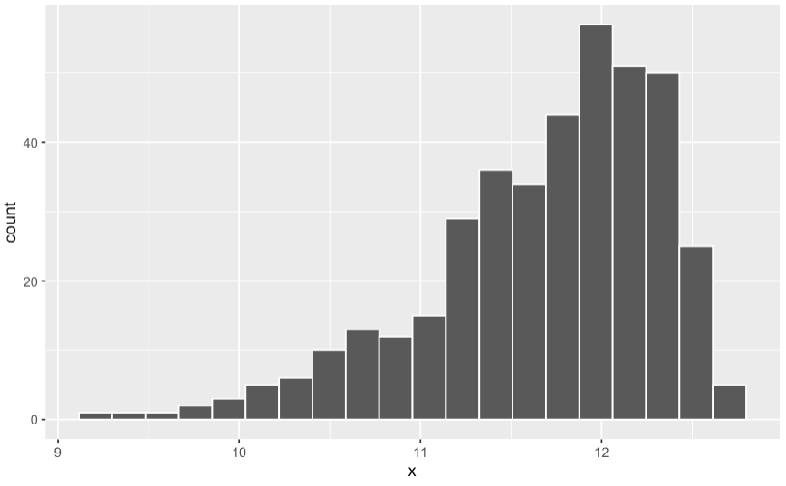

In a **left-skewed** distribution, the centrality measures **typically** fall in the order

$$\textrm{mean} \lt \textrm{median} \lt \textrm{mode}$$

## 6.2 Right skewness

Right skewed data is the opposite of left skewed. For right skewed data, the tail should be pointing towards the right.

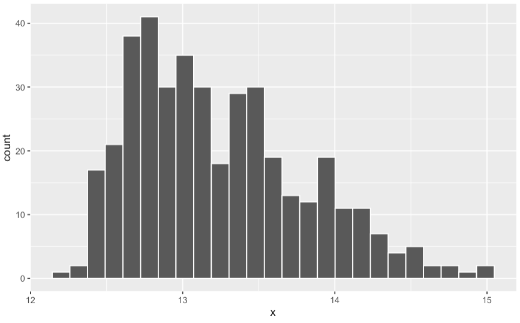

The measures fall in the order $\textrm{mode} \lt \textrm{median} \lt \textrm{mean}$.

**Optional - binning a continuous variable**

In the above example, variable `x` dataset is continuous numeric variable.

How do we interpret the mode of a continuous variable? Essentially, every `x` value is (or has the potential to be) unique, and occurs with frequency $1$, so what does mode mean in this context?

We can ‘bin’ a continuous variable to get around this problem: in short, this converts the variable from continuous to factor. Here’s a picture that might help to explain the process.

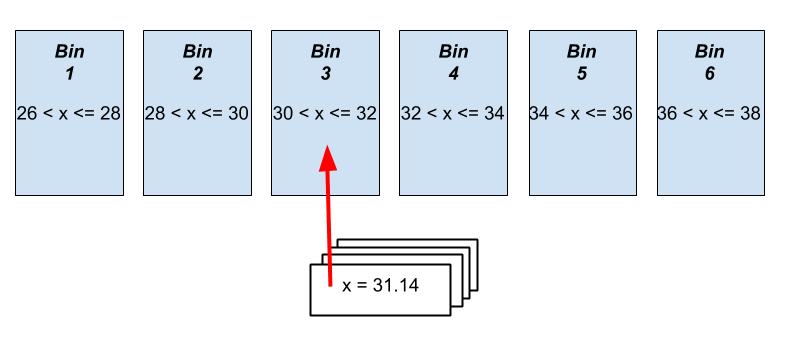

**Fig. 1.** Binning a continuous variable

To do this, we set up a series of ‘bins’ into which we sort the values in the distribution, one-by-one. The `cut()` function in base R does this for us. We specify a number of `breaks` to use:

```r
left_skewed <- read_csv("data/leftskew.csv")
binned_left_skewed <- cut(left_skewed$x, breaks = 25)
head(binned_left_skewed)
```

```
## [1] (11.8,11.9] (12.4,12.5] (11.8,11.9] (12.1,12.2] (10.5,10.7] (11.4,11.5]
## 25 Levels: (9.28,9.43] (9.43,9.57] (9.57,9.71] (9.71,9.85] ... (12.6,12.8]
```

The variable has been converted to `factor` type, with a number of levels equal to the `breaks` parameter. What does `(11.8, 11.9]` mean? This is just **interval notation** in maths: this means $11.8 \lt x \le 11.9$, i.e. this bin ‘grabs’ all the values in that range.

Now that we’ve seen how we can bin a continuous variable, we’ll do this before we calculate the mode

```r
left_skewed %>%
  mutate(binned = cut(x, breaks = 25)) %>%
  summarise(mode_daily_sales = get_mode(binned))
```

| mode_daily_sales |
| --- |
| (11.9,12.1] |

So the mode falls within the range 11.9 to 12.1. This puts the centrality measures in the order $\textrm{mean} \lt \textrm{median} \lt \textrm{mode}$, as expected. Note that the term ‘left’ in the name ‘left-skewed’ refers to the direction in which the ‘long tail’ points!

## 6.3 Measure of skewness

We can compute the `skewness()` of a distribution prior to further analyses. A **negative** value correspond to left-skew, and a **positive** value to right-skew. The magnitude of the skewness (i.e. the value ignoring the sign) can be interpreted on the following table.

| Magnitude of Skewness | Classification |
| --- | --- |
| < 0.5 | fairly symmetrical |
| 0.5 - 1.0 | moderately skewed |
| > 1.0 | highly skewed |

```r
library(e1071) # rolls of the tongue, doesn't it
left_skewed <- read_csv("data/leftskew.csv")
right_skewed <- read_csv("data/rightskew.csv")

left_skewed %>%
  # highly left skewed
  summarise(skewness = skewness(x, type = 1))
```

| skewness |
| --- |
| -1.011889 |

```r
right_skewed %>%
  # moderately right skewed
  summarise(skewness = skewness(x, type = 1))
```

| skewness |
| --- |
| 0.6736541 |

We should try not to use the mean as a measure of centrality for moderately and highly skewed distributions, preferring the median instead in these cases.

> **Task - 2 mins** Calculate and interpret the skewness of the `units_sold` variable in `air_con_sales`:
> - is the distribution significantly skewed?
> - if significantly skewed, is it left- or right-skewed?

> **Solution**

> ```r
> air_con_sales %>%
>   summarise(skewness = skewness(units_sold, type = 1))
> ```

> | skewness |
> | --- |
> | 3.824317 |

> The distribution is highly right-skewed.

# 7 The key message

Why does distribution shape and skewness matter? It will become clearer later, but the TL;DR version is that all statistical tests have assumptions about the underlying distribution of data. And if your data doesn’t meet these assumptions, you will have to use a different statistical test. The only way you can ensure you’re using the correct test is to look at your data carefully and assess the underlying distribution.

We’ve been saying this a lot, but it bears repeating:

**“Always visualise your data before performing any further statistical analyses!”**

# 8 Recap

- What is a distribution?

  **Answer**

  The distribution is a function that tells us either the *frequency* or *probability* of each outcome in the sample space of an experiment (we would speak of the **frequency distribution** or **probability distribution** respectively)
- Define mean, median and mode

  **Answer**
  - The **mean** is the sum of all values divided by the number of values.
  - The **mode** is the most likely value in the data set, i.e. the value that occurs most frequently.
  - The **median** is the ‘middle’ value of the sorted data set.
- What are unimodal, bimodal and multimodal distributions?

  **Answer**

  A **unimodal** distribution is one in which there is **a single** ‘peak’ or ‘hump’ in the data, a **bimodal** distribution has two humps, and **multimodal** data has more than two.
- What is the skewness of a distribution?

  **Answer**

  **Skewness** in a distribution refers to **asymmetry**, to a tendency to be distorted to the left or right.
- Which centrality measures should you be careful of for data with outliers, bimodal and multimodal data, and skewed data?